# Risk Factor Analysis

## Outcome Variable

**Outcome Variable:** sstunted

## Predictor Variables

**Intervention Variable:** exclfeed3

**Adjustment Set:**

unadjusted

## Stratifying Variables

The analysis was stratified on these variable(s):

- agecat
- studyid
- country

## Data Summary

| agecat | studyid | country | exclfeed3 | sstunted | n_cell | n |
| --- | --- | --- | --- | --- | --- | --- |
| Birth | CMC-V-BCS-2002 | INDIA | 1 | 0 | 4 | 4 |
| Birth | CMC-V-BCS-2002 | INDIA | 1 | 1 | 0 | 4 |
| Birth | CMC-V-BCS-2002 | INDIA | 0 | 0 | 0 | 4 |
| Birth | CMC-V-BCS-2002 | INDIA | 0 | 1 | 0 | 4 |
| Birth | EE | PAKISTAN | 1 | 0 | 28 | 35 |
| Birth | EE | PAKISTAN | 1 | 1 | 7 | 35 |
| Birth | EE | PAKISTAN | 0 | 0 | 0 | 35 |
| Birth | EE | PAKISTAN | 0 | 1 | 0 | 35 |
| Birth | GMS-Nepal | NEPAL | 1 | 0 | 367 | 458 |
| Birth | GMS-Nepal | NEPAL | 1 | 1 | 13 | 458 |
| Birth | GMS-Nepal | NEPAL | 0 | 0 | 73 | 458 |
| Birth | GMS-Nepal | NEPAL | 0 | 1 | 5 | 458 |
| Birth | IRC | INDIA | 1 | 0 | 0 | 10 |
| Birth | IRC | INDIA | 1 | 1 | 0 | 10 |
| Birth | IRC | INDIA | 0 | 0 | 10 | 10 |
| Birth | IRC | INDIA | 0 | 1 | 0 | 10 |
| Birth | JiVitA-3 | BANGLADESH | 1 | 0 | 10706 | 13276 |
| Birth | JiVitA-3 | BANGLADESH | 1 | 1 | 1308 | 13276 |
| Birth | JiVitA-3 | BANGLADESH | 0 | 0 | 1118 | 13276 |
| Birth | JiVitA-3 | BANGLADESH | 0 | 1 | 144 | 13276 |
| Birth | JiVitA-4 | BANGLADESH | 1 | 0 | 97 | 116 |
| Birth | JiVitA-4 | BANGLADESH | 1 | 1 | 8 | 116 |
| Birth | JiVitA-4 | BANGLADESH | 0 | 0 | 9 | 116 |
| Birth | JiVitA-4 | BANGLADESH | 0 | 1 | 2 | 116 |
| Birth | Keneba | GAMBIA | 1 | 0 | 1171 | 1356 |
| Birth | Keneba | GAMBIA | 1 | 1 | 27 | 1356 |
| Birth | Keneba | GAMBIA | 0 | 0 | 156 | 1356 |
| Birth | Keneba | GAMBIA | 0 | 1 | 2 | 1356 |
| Birth | MAL-ED | BANGLADESH | 1 | 0 | 135 | 215 |
| Birth | MAL-ED | BANGLADESH | 1 | 1 | 3 | 215 |

[output cut: 158 more lines]

The following strata were considered:

- agecat: 24 months, studyid: CMC-V-BCS-2002, country: INDIA
- agecat: 24 months, studyid: EE, country: PAKISTAN
- agecat: 24 months, studyid: GMS-Nepal, country: NEPAL
- agecat: 24 months, studyid: IRC, country: INDIA
- agecat: 24 months, studyid: JiVitA-3, country: BANGLADESH
- agecat: 24 months, studyid: JiVitA-4, country: BANGLADESH
- agecat: 24 months, studyid: Keneba, country: GAMBIA
- agecat: 24 months, studyid: MAL-ED, country: BANGLADESH
- agecat: 24 months, studyid: MAL-ED, country: BRAZIL
- agecat: 24 months, studyid: MAL-ED, country: INDIA
- agecat: 24 months, studyid: MAL-ED, country: NEPAL
- agecat: 24 months, studyid: MAL-ED, country: PERU
- agecat: 24 months, studyid: MAL-ED, country: SOUTH AFRICA
- agecat: 24 months, studyid: MAL-ED, country: TANZANIA, UNITED REPUBLIC OF
- agecat: 24 months, studyid: PROVIDE, country: BANGLADESH
- agecat: 6 months, studyid: CMC-V-BCS-2002, country: INDIA
- agecat: 6 months, studyid: EE, country: PAKISTAN
- agecat: 6 months, studyid: GMS-Nepal, country: NEPAL
- agecat: 6 months, studyid: IRC, country: INDIA
- agecat: 6 months, studyid: JiVitA-3, country: BANGLADESH
- agecat: 6 months, studyid: JiVitA-4, country: BANGLADESH
- agecat: 6 months, studyid: Keneba, country: GAMBIA
- agecat: 6 months, studyid: MAL-ED, country: BANGLADESH
- agecat: 6 months, studyid: MAL-ED, country: BRAZIL
- agecat: 6 months, studyid: MAL-ED, country: INDIA
- agecat: 6 months, studyid: MAL-ED, country: NEPAL
- agecat: 6 months, studyid: MAL-ED, country: PERU
- agecat: 6 months, studyid: MAL-ED, country: SOUTH AFRICA
- agecat: 6 months, studyid: MAL-ED, country: TANZANIA, UNITED REPUBLIC OF
- agecat: 6 months, studyid: PROVIDE, country: BANGLADESH
- agecat: 6 months, studyid: SAS-CompFeed, country: INDIA
- agecat: Birth, studyid: CMC-V-BCS-2002, country: INDIA
- agecat: Birth, studyid: EE, country: PAKISTAN
- agecat: Birth, studyid: GMS-Nepal, country: NEPAL
- agecat: Birth, studyid: IRC, country: INDIA
- agecat: Birth, studyid: JiVitA-3, country: BANGLADESH
- agecat: Birth, studyid: JiVitA-4, country: BANGLADESH
- agecat: Birth, studyid: Keneba, country: GAMBIA
- agecat: Birth, studyid: MAL-ED, country: BANGLADESH
- agecat: Birth, studyid: MAL-ED, country: BRAZIL
- agecat: Birth, studyid: MAL-ED, country: INDIA
- agecat: Birth, studyid: MAL-ED, country: NEPAL
- agecat: Birth, studyid: MAL-ED, country: PERU
- agecat: Birth, studyid: MAL-ED, country: SOUTH AFRICA
- agecat: Birth, studyid: MAL-ED, country: TANZANIA, UNITED REPUBLIC OF
- agecat: Birth, studyid: PROVIDE, country: BANGLADESH
- agecat: Birth, studyid: SAS-CompFeed, country: INDIA

### Dropped Strata

Some strata were dropped due to rare outcomes:

- agecat: Birth, studyid: CMC-V-BCS-2002, country: INDIA
- agecat: Birth, studyid: EE, country: PAKISTAN
- agecat: Birth, studyid: IRC, country: INDIA
- agecat: Birth, studyid: JiVitA-4, country: BANGLADESH
- agecat: Birth, studyid: Keneba, country: GAMBIA
- agecat: Birth, studyid: MAL-ED, country: BANGLADESH
- agecat: Birth, studyid: MAL-ED, country: BRAZIL
- agecat: Birth, studyid: MAL-ED, country: INDIA
- agecat: Birth, studyid: MAL-ED, country: NEPAL
- agecat: Birth, studyid: MAL-ED, country: PERU
- agecat: Birth, studyid: MAL-ED, country: SOUTH AFRICA
- agecat: Birth, studyid: MAL-ED, country: TANZANIA, UNITED REPUBLIC OF
- agecat: Birth, studyid: PROVIDE, country: BANGLADESH
- agecat: Birth, studyid: SAS-CompFeed, country: INDIA
- agecat: 6 months, studyid: CMC-V-BCS-2002, country: INDIA
- agecat: 6 months, studyid: EE, country: PAKISTAN
- agecat: 6 months, studyid: IRC, country: INDIA
- agecat: 6 months, studyid: JiVitA-4, country: BANGLADESH
- agecat: 6 months, studyid: MAL-ED, country: BANGLADESH
- agecat: 6 months, studyid: MAL-ED, country: BRAZIL
- agecat: 6 months, studyid: MAL-ED, country: INDIA
- agecat: 6 months, studyid: MAL-ED, country: NEPAL
- agecat: 6 months, studyid: MAL-ED, country: PERU
- agecat: 6 months, studyid: MAL-ED, country: SOUTH AFRICA
- agecat: 6 months, studyid: MAL-ED, country: TANZANIA, UNITED REPUBLIC OF
- agecat: 6 months, studyid: SAS-CompFeed, country: INDIA
- agecat: 24 months, studyid: CMC-V-BCS-2002, country: INDIA
- agecat: 24 months, studyid: EE, country: PAKISTAN
- agecat: 24 months, studyid: IRC, country: INDIA
- agecat: 24 months, studyid: JiVitA-4, country: BANGLADESH
- agecat: 24 months, studyid: MAL-ED, country: BRAZIL
- agecat: 24 months, studyid: MAL-ED, country: NEPAL
- agecat: 24 months, studyid: MAL-ED, country: PERU
- agecat: 24 months, studyid: MAL-ED, country: SOUTH AFRICA

## Methods Detail

We’re interested in the causal parameters $E[Y_a]$ for all values of $a \in \mathcal{A}$. These parameters represent the mean outcome if, possibly contrary to fact, we intervened to set all units to have $A=a$. Under the randomization and positivity assumptions, these are identified by the statistical parameters $\psi_a=E_W[E_{Y|A,W}(Y|A=a,W)]$. In addition, we’re interested in the mean of $Y$, $E[Y]$ under no intervention (the observed mean). We will estimate these parameters by using SuperLearner to fit the relevant likelihood factors – $E_{Y|A,W}(Y|A=a,W)$ and $p(A=a|W)$, and then updating our likelihood fit using a joint TMLE.

For unadjusted analyses ($W=\{\}$), initial likelihoods were estimated using Lrnr_glm to estimate the simple $E(Y|A)$ and Lrnr_mean to estimate $p(A)$. For adjusted analyses, a small library containing Lrnr_glmnet, Lrnr_xgboost, and Lrnr_mean was used.

Having estimated these parameters, we will then use the delta method to estimate relative risks and attributable risks relative to a prespecified baseline level of $A$.

# Results Detail

## Results Plots

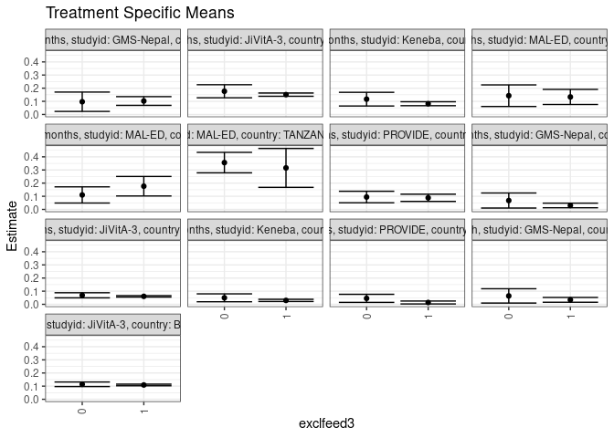

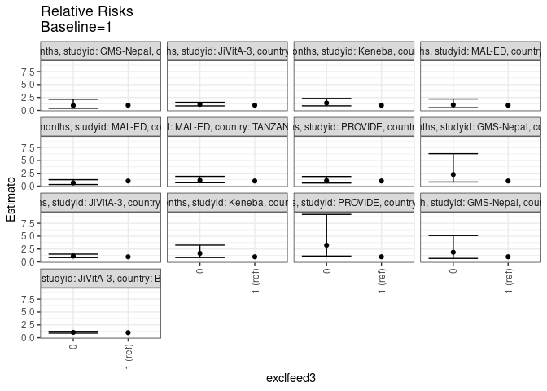

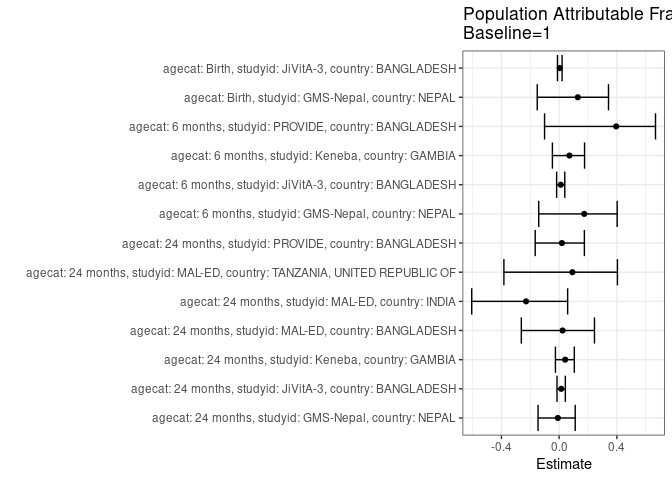

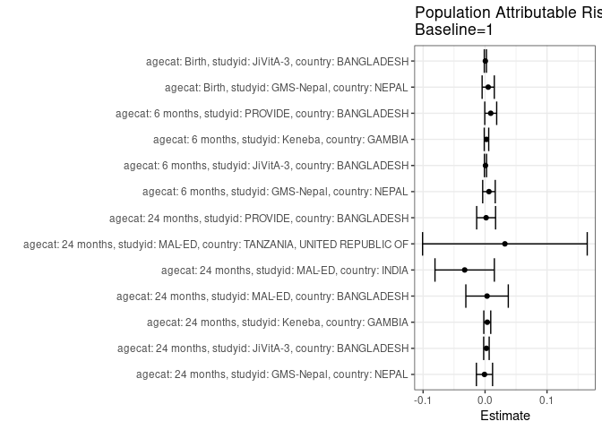

## Results Table

### Parameter: TSM

| agecat | studyid | country | intervention_level | baseline_level | estimate | ci_lower | ci_upper |
| --- | --- | --- | --- | --- | --- | --- | --- |
| Birth | GMS-Nepal | NEPAL | 1 | NA | 0.0342105 | 0.0159147 | 0.0525064 |
| Birth | GMS-Nepal | NEPAL | 0 | NA | 0.0641026 | 0.0096865 | 0.1185186 |
| Birth | JiVitA-3 | BANGLADESH | 1 | NA | 0.1088730 | 0.1027448 | 0.1150011 |
| Birth | JiVitA-3 | BANGLADESH | 0 | NA | 0.1141046 | 0.0968916 | 0.1313175 |
| 6 months | GMS-Nepal | NEPAL | 1 | NA | 0.0299728 | 0.0125080 | 0.0474375 |
| 6 months | GMS-Nepal | NEPAL | 0 | NA | 0.0675676 | 0.0103139 | 0.1248212 |
| 6 months | JiVitA-3 | BANGLADESH | 1 | NA | 0.0608410 | 0.0552914 | 0.0663905 |
| 6 months | JiVitA-3 | BANGLADESH | 0 | NA | 0.0687961 | 0.0494255 | 0.0881667 |
| 6 months | Keneba | GAMBIA | 1 | NA | 0.0298507 | 0.0213517 | 0.0383498 |
| 6 months | Keneba | GAMBIA | 0 | NA | 0.0497512 | 0.0196839 | 0.0798186 |
| 6 months | PROVIDE | BANGLADESH | 1 | NA | 0.0140187 | 0.0028713 | 0.0251661 |
| 6 months | PROVIDE | BANGLADESH | 0 | NA | 0.0454545 | 0.0146554 | 0.0762537 |
| 24 months | GMS-Nepal | NEPAL | 1 | NA | 0.1024845 | 0.0693152 | 0.1356538 |
| 24 months | GMS-Nepal | NEPAL | 0 | NA | 0.0967742 | 0.0230863 | 0.1704621 |
| 24 months | JiVitA-3 | BANGLADESH | 1 | NA | 0.1509136 | 0.1385391 | 0.1632881 |
| 24 months | JiVitA-3 | BANGLADESH | 0 | NA | 0.1766110 | 0.1268233 | 0.2263986 |
| 24 months | Keneba | GAMBIA | 1 | NA | 0.0816327 | 0.0665924 | 0.0966730 |
| 24 months | Keneba | GAMBIA | 0 | NA | 0.1164384 | 0.0643919 | 0.1684848 |
| 24 months | MAL-ED | BANGLADESH | 1 | NA | 0.1333333 | 0.0758505 | 0.1908162 |
| 24 months | MAL-ED | BANGLADESH | 0 | NA | 0.1428571 | 0.0606824 | 0.2250319 |
| 24 months | MAL-ED | INDIA | 1 | NA | 0.1764706 | 0.1023052 | 0.2506360 |
| 24 months | MAL-ED | INDIA | 0 | NA | 0.1100000 | 0.0485224 | 0.1714776 |
| 24 months | MAL-ED | TANZANIA, UNITED REPUBLIC OF | 1 | NA | 0.3157895 | 0.1675945 | 0.4639844 |
| 24 months | MAL-ED | TANZANIA, UNITED REPUBLIC OF | 0 | NA | 0.3561644 | 0.2782769 | 0.4340519 |
| 24 months | PROVIDE | BANGLADESH | 1 | NA | 0.0882353 | 0.0606894 | 0.1157812 |
| 24 months | PROVIDE | BANGLADESH | 0 | NA | 0.0941176 | 0.0501866 | 0.1380486 |

### Parameter: E(Y)

| agecat | studyid | country | intervention_level | baseline_level | estimate | ci_lower | ci_upper |
| --- | --- | --- | --- | --- | --- | --- | --- |
| Birth | GMS-Nepal | NEPAL | NA | NA | 0.0393013 | 0.0214863 | 0.0571164 |
| Birth | JiVitA-3 | BANGLADESH | NA | NA | 0.1093703 | 0.1036242 | 0.1151164 |
| 6 months | GMS-Nepal | NEPAL | NA | NA | 0.0362812 | 0.0188094 | 0.0537530 |
| 6 months | JiVitA-3 | BANGLADESH | NA | NA | 0.0615352 | 0.0561307 | 0.0669396 |
| 6 months | Keneba | GAMBIA | NA | NA | 0.0321470 | 0.0238614 | 0.0404325 |
| 6 months | PROVIDE | BANGLADESH | NA | NA | 0.0231788 | 0.0111688 | 0.0351888 |
| 24 months | GMS-Nepal | NEPAL | NA | NA | 0.1015625 | 0.0713101 | 0.1318149 |
| 24 months | JiVitA-3 | BANGLADESH | NA | NA | 0.1531327 | 0.1409934 | 0.1652721 |
| 24 months | Keneba | GAMBIA | NA | NA | 0.0852113 | 0.0706846 | 0.0997379 |
| 24 months | MAL-ED | BANGLADESH | NA | NA | 0.1365854 | 0.0894611 | 0.1837097 |
| 24 months | MAL-ED | INDIA | NA | NA | 0.1435644 | 0.0950890 | 0.1920397 |
| 24 months | MAL-ED | TANZANIA, UNITED REPUBLIC OF | NA | NA | 0.3478261 | 0.2788203 | 0.4168318 |
| 24 months | PROVIDE | BANGLADESH | NA | NA | 0.0899654 | 0.0666186 | 0.1133122 |

### Parameter: RR

| agecat | studyid | country | intervention_level | baseline_level | estimate | ci_lower | ci_upper |
| --- | --- | --- | --- | --- | --- | --- | --- |
| Birth | GMS-Nepal | NEPAL | 1 | 1 | 1.0000000 | 1.0000000 | 1.000000 |
| Birth | GMS-Nepal | NEPAL | 0 | 1 | 1.8737673 | 0.6870436 | 5.110307 |
| Birth | JiVitA-3 | BANGLADESH | 1 | 1 | 1.0000000 | 1.0000000 | 1.000000 |
| Birth | JiVitA-3 | BANGLADESH | 0 | 1 | 1.0480525 | 0.8911531 | 1.232576 |
| 6 months | GMS-Nepal | NEPAL | 1 | 1 | 1.0000000 | 1.0000000 | 1.000000 |
| 6 months | GMS-Nepal | NEPAL | 0 | 1 | 2.2542998 | 0.8061176 | 6.304126 |
| 6 months | JiVitA-3 | BANGLADESH | 1 | 1 | 1.0000000 | 1.0000000 | 1.000000 |
| 6 months | JiVitA-3 | BANGLADESH | 0 | 1 | 1.1307524 | 0.8440955 | 1.514759 |
| 6 months | Keneba | GAMBIA | 1 | 1 | 1.0000000 | 1.0000000 | 1.000000 |
| 6 months | Keneba | GAMBIA | 0 | 1 | 1.6666667 | 0.8545016 | 3.250758 |
| 6 months | PROVIDE | BANGLADESH | 1 | 1 | 1.0000000 | 1.0000000 | 1.000000 |
| 6 months | PROVIDE | BANGLADESH | 0 | 1 | 3.2424242 | 1.1406585 | 9.216883 |
| 24 months | GMS-Nepal | NEPAL | 1 | 1 | 1.0000000 | 1.0000000 | 1.000000 |
| 24 months | GMS-Nepal | NEPAL | 0 | 1 | 0.9442815 | 0.4128367 | 2.159855 |
| 24 months | JiVitA-3 | BANGLADESH | 1 | 1 | 1.0000000 | 1.0000000 | 1.000000 |
| 24 months | JiVitA-3 | BANGLADESH | 0 | 1 | 1.1702787 | 0.8729152 | 1.568941 |
| 24 months | Keneba | GAMBIA | 1 | 1 | 1.0000000 | 1.0000000 | 1.000000 |
| 24 months | Keneba | GAMBIA | 0 | 1 | 1.4263699 | 0.8795566 | 2.313133 |
| 24 months | MAL-ED | BANGLADESH | 1 | 1 | 1.0000000 | 1.0000000 | 1.000000 |
| 24 months | MAL-ED | BANGLADESH | 0 | 1 | 1.0714286 | 0.5221195 | 2.198652 |
| 24 months | MAL-ED | INDIA | 1 | 1 | 1.0000000 | 1.0000000 | 1.000000 |
| 24 months | MAL-ED | INDIA | 0 | 1 | 0.6233333 | 0.3097633 | 1.254327 |
| 24 months | MAL-ED | TANZANIA, UNITED REPUBLIC OF | 1 | 1 | 1.0000000 | 1.0000000 | 1.000000 |
| 24 months | MAL-ED | TANZANIA, UNITED REPUBLIC OF | 0 | 1 | 1.1278539 | 0.6720524 | 1.892791 |
| 24 months | PROVIDE | BANGLADESH | 1 | 1 | 1.0000000 | 1.0000000 | 1.000000 |
| 24 months | PROVIDE | BANGLADESH | 0 | 1 | 1.0666667 | 0.6083496 | 1.870270 |

### Parameter: PAR

| agecat | studyid | country | intervention_level | baseline_level | estimate | ci_lower | ci_upper |
| --- | --- | --- | --- | --- | --- | --- | --- |
| Birth | GMS-Nepal | NEPAL | 1 | NA | 0.0050908 | -0.0047405 | 0.0149221 |
| Birth | JiVitA-3 | BANGLADESH | 1 | NA | 0.0004973 | -0.0012499 | 0.0022445 |
| 6 months | GMS-Nepal | NEPAL | 1 | NA | 0.0063084 | -0.0038212 | 0.0164381 |
| 6 months | JiVitA-3 | BANGLADESH | 1 | NA | 0.0006942 | -0.0010457 | 0.0024341 |
| 6 months | Keneba | GAMBIA | 1 | NA | 0.0022962 | -0.0013214 | 0.0059138 |
| 6 months | PROVIDE | BANGLADESH | 1 | NA | 0.0091601 | -0.0004521 | 0.0187723 |
| 24 months | GMS-Nepal | NEPAL | 1 | NA | -0.0009220 | -0.0139710 | 0.0121270 |
| 24 months | JiVitA-3 | BANGLADESH | 1 | NA | 0.0022191 | -0.0022283 | 0.0066665 |
| 24 months | Keneba | GAMBIA | 1 | NA | 0.0035786 | -0.0020187 | 0.0091759 |
| 24 months | MAL-ED | BANGLADESH | 1 | NA | 0.0032520 | -0.0309971 | 0.0375011 |
| 24 months | MAL-ED | INDIA | 1 | NA | -0.0329062 | -0.0808165 | 0.0150041 |
| 24 months | MAL-ED | TANZANIA, UNITED REPUBLIC OF | 1 | NA | 0.0320366 | -0.1008256 | 0.1648989 |
| 24 months | PROVIDE | BANGLADESH | 1 | NA | 0.0017301 | -0.0135223 | 0.0169825 |

### Parameter: PAF

| agecat | studyid | country | intervention_level | baseline_level | estimate | ci_lower | ci_upper |
| --- | --- | --- | --- | --- | --- | --- | --- |
| Birth | GMS-Nepal | NEPAL | 1 | NA | 0.1295322 | -0.1516576 | 0.3420664 |
| Birth | JiVitA-3 | BANGLADESH | 1 | NA | 0.0045470 | -0.0115767 | 0.0204137 |
| 6 months | GMS-Nepal | NEPAL | 1 | NA | 0.1738760 | -0.1415465 | 0.4021437 |
| 6 months | JiVitA-3 | BANGLADESH | 1 | NA | 0.0112813 | -0.0173412 | 0.0390984 |
| 6 months | Keneba | GAMBIA | 1 | NA | 0.0714286 | -0.0466034 | 0.1761494 |
| 6 months | PROVIDE | BANGLADESH | 1 | NA | 0.3951936 | -0.1009314 | 0.6677442 |
| 24 months | GMS-Nepal | NEPAL | 1 | NA | -0.0090779 | -0.1460736 | 0.1115420 |
| 24 months | JiVitA-3 | BANGLADESH | 1 | NA | 0.0144915 | -0.0148530 | 0.0429875 |
| 24 months | Keneba | GAMBIA | 1 | NA | 0.0419970 | -0.0256507 | 0.1051828 |
| 24 months | MAL-ED | BANGLADESH | 1 | NA | 0.0238095 | -0.2619716 | 0.2448738 |
| 24 months | MAL-ED | INDIA | 1 | NA | -0.2292089 | -0.6056616 | 0.0589832 |
| 24 months | MAL-ED | TANZANIA, UNITED REPUBLIC OF | 1 | NA | 0.0921053 | -0.3827696 | 0.4038972 |
| 24 months | PROVIDE | BANGLADESH | 1 | NA | 0.0192308 | -0.1657700 | 0.1748730 |